# Surface Energy Fluxes

This report plots the surface energy balance computed by `run_ice_model()` for every lake with a saved model output in Data/model_outputs. Output files used: ELB_2017_2024_output.csv, GL4_2014_2025_output.csv, LF_2017_2024_output.csv, LH_2017_2024_output.csv, LOC_2017_2024_output.csv, WLB_2017_2024_output.csv.

**Sign convention.** Every flux is in W m<sup>-2</sup> and positive means energy *into* the ice surface (warming it, or melting it once it is at 0 °C); negative means energy leaving the surface. Conduction is plotted as **-Qc** so it reads the same way: positive is heat conducted up to the surface from the warmer ice below (winter), negative is heat conducted from the surface down into the ice (spring and summer warming). `SW_abs` is the shortwave absorbed *at the surface* only; the share that penetrates into the ice (`SW_pen`, i0 of the net shortwave) is not part of the surface budget.

| Flux | Positive | Negative |
| --- | --- | --- |
| SW_abs | Sunlight absorbed at the surface | Never (0 at night) |
| LW_net | Sky emits more than the ice (rare) | Ice radiates more than it receives (usual) |
| Qh | Air warmer than the surface | Surface warmer than the air |
| Ql | Condensation / frost deposition | Sublimation (or evaporation) |
| -Qc | Heat conducted up from the ice below | Heat conducted down into the ice |
| Net | Surface gains energy; melts at 0 °C | Surface cools; no surface melt |

# A. Flux time series

Seven-day running means of the daily mean fluxes. Each flux panel has its own y-axis. For the seasonally frozen lakes, open-water periods are shaded blue.

## Net surface flux, all lakes

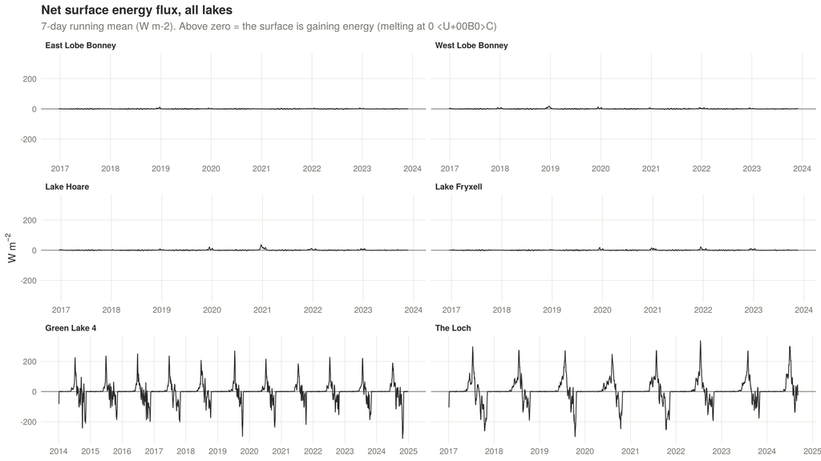

## Individual fluxes by lake

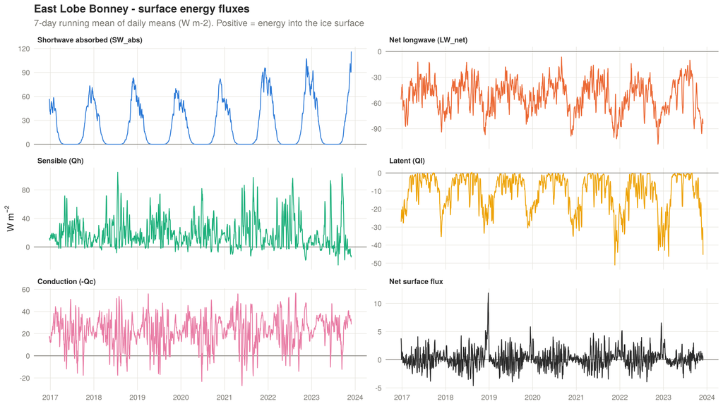

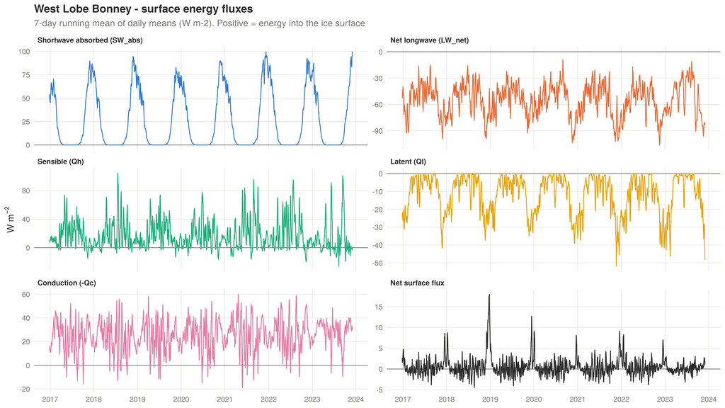

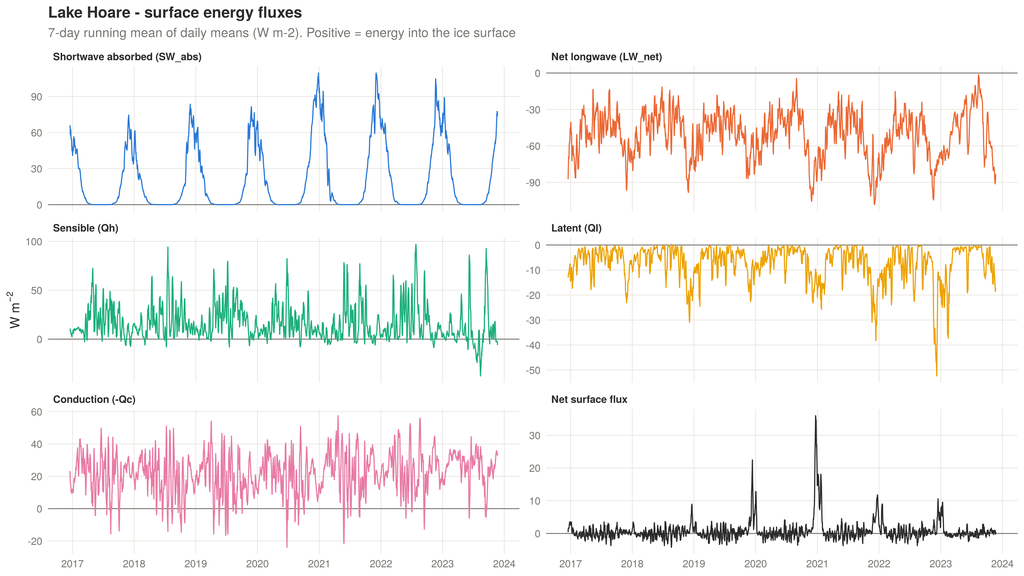

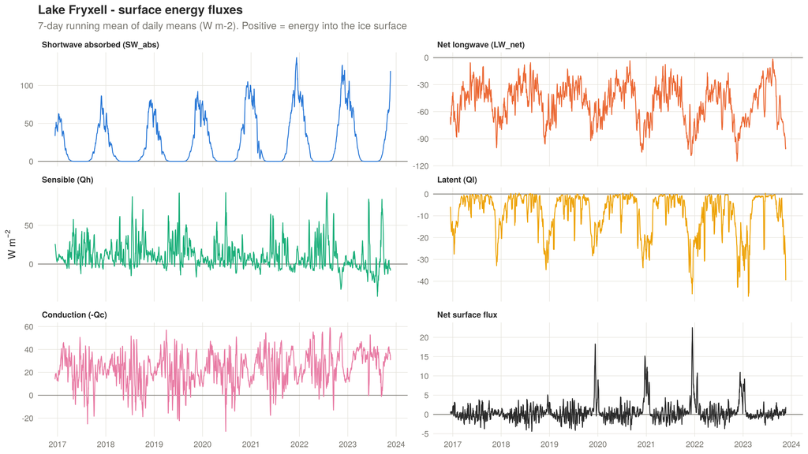

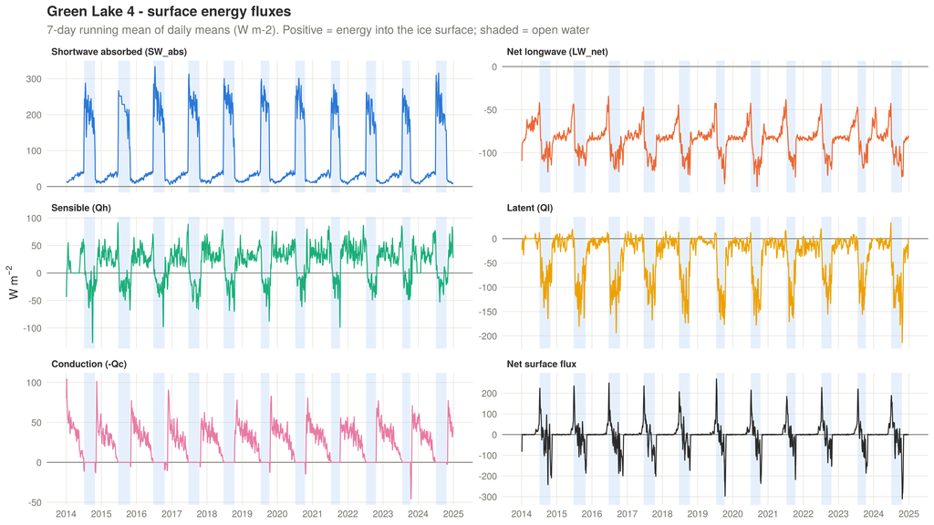

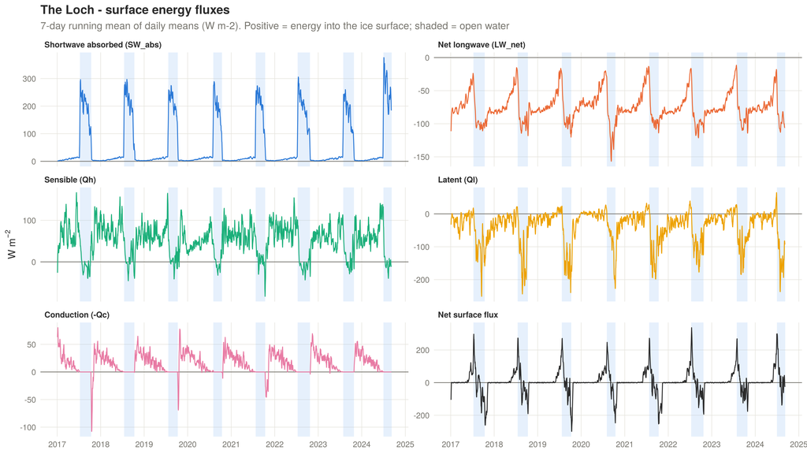

# B. Fluxes leading to ice-off and through the warmest months

## Seasonal lakes: the 60 days before ice-off

Day 0 is the modelled ice-off date each year. Lines are the mean across years and bands the interquartile range, both 7-day smoothed.

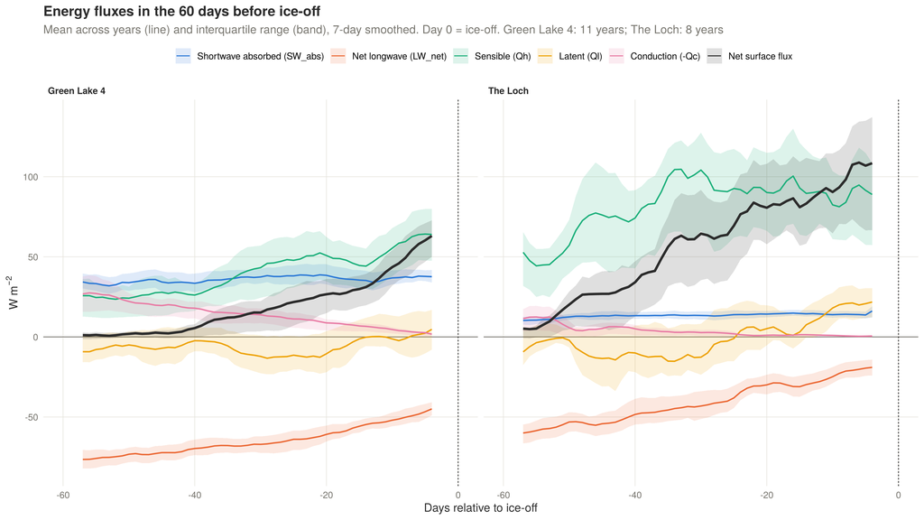

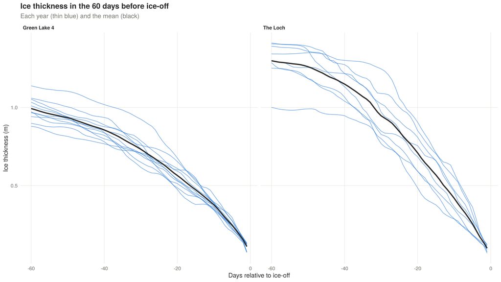

## Dry Valley lakes: the austral summer (1 Dec - 28 Feb)

The perennially frozen lakes never open, so the window is the warmest three months.

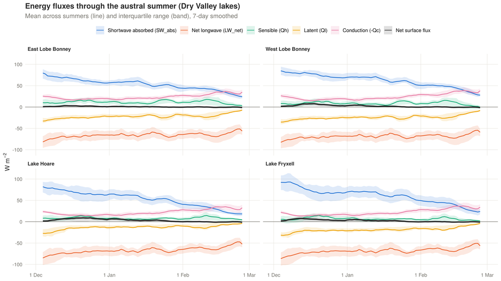

## Mean energy budget in the melt window

Seasonal lakes: the last 30 days before ice-off. Dry Valley lakes: 1 Dec - 28 Feb.

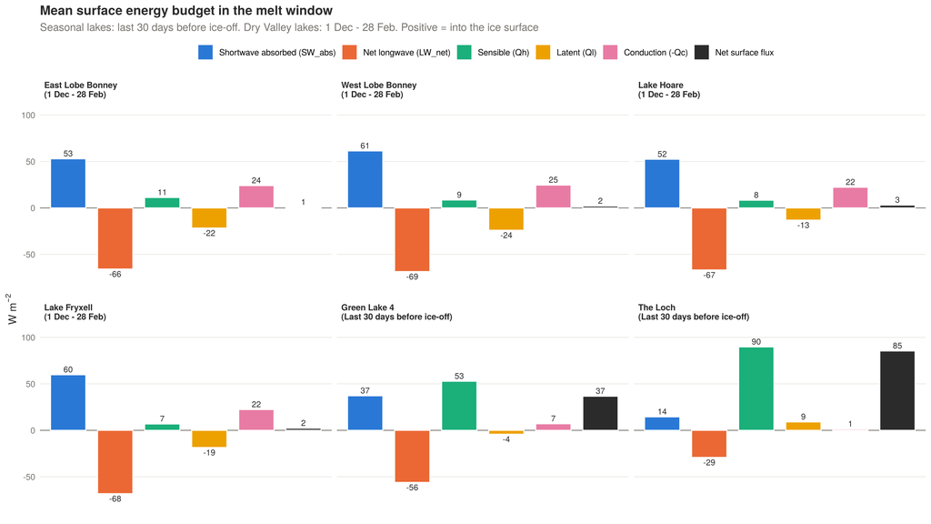

Mean flux in the melt window (W m-2; positive = into the ice surface)

| lake | window | Shortwave absorbed | Net longwave | Sensible | Latent | Conduction | Net surface flux |
| --- | --- | --- | --- | --- | --- | --- | --- |
| East Lobe Bonney | 1 Dec - 28 Feb | 53 | -66 | 11 | -22 | 24 | 1 |
| West Lobe Bonney | 1 Dec - 28 Feb | 61 | -69 | 9 | -24 | 25 | 2 |
| Lake Hoare | 1 Dec - 28 Feb | 52 | -67 | 8 | -13 | 22 | 3 |
| Lake Fryxell | 1 Dec - 28 Feb | 60 | -68 | 7 | -19 | 22 | 2 |
| Green Lake 4 | Last 30 days before ice-off | 37 | -56 | 53 | -4 | 7 | 37 |
| The Loch | Last 30 days before ice-off | 14 | -29 | 90 | 9 | 1 | 85 |